# MA5851: DATA SCIENCE MASTERCLASS 1

## A3: WebCrawler and NLP System

### D2: WebCrawler

### The Website

Successfully launched in 2007 and purchased by Amazon in 2013, Demarest (2021) describes Goodreads as a book-centric review website that allows readers to track and share books they read with a recommender engine proposing new titles based on their interactions with the site. Beyond this, users can search titles, authors, and user reviews, with options to for flagging titles as “reading” or “to-read”.

Supporting the recommendation engine is a growing community of readers providing independent reviews and metadata on the content they consume. As of 2019 the site had >90 million users, with publishers latching onto this massive userbase as a free test group (Wille, 2021). Owing to the sample sizes and metadata available by title, this represents a potential scrapable database of current independent review content for analysis. Also, given the consistent structure of the site, this provides an opportunity for creating a repeatable scraping, processing, and analysis pipeline.

### Potential Data

The site is broken into three channels; “My Books” (to review content consumed), “Browse” (to view titles by categories or genres), and “Community” (for to discussion groups). With a function of “My Books” being custom bookshelves, where users create shelves to organise their reading material. This provides access to subgenres to view direct competitor content. Here grimdark (a subgenre of fantasy) is the focus, but there are over 10,000 shelves on the site.

With regard to copyright considerations of scraping, the Goodreads Terms and Conditions (2021) for registered users states, “No part of the Service may be reproduced, duplicated, copied, sold, resold, visited, or otherwise exploited for any commercial purpose without our express written consent”. In short, all user derived metadata on the site is Amazon’s IP and may not be reproduced or used for commercial benefit.

However, Seville (2019) indicates Australian copywrite laws only protect those who produce original work, but that data isn’t considered original because it is fact-based. Further, where infringement is alleged, exceptions known as ‘fair dealing’ (e.g., for research or study purposes) can be used to escape penalties. For this reason, scraping data from Goodreads is allowed, especially when being conducted for research or study.

### The Crawler

The purpose of this crawler is to seamlessly access and locate a range of active web pages associated with the “grimdark” sub-genre within the extensive Goodreads platform. Once each page is individually loaded, the crawler must copy and retrieve select content as available from each page and append the results to a single dataframe. But as with all journeys, this begins with a single step, which involved manually navigating to a “grimdark” shelf page and examining the underlying structure to become more familiar with the branches as shown below.

[figure not shown]

Once familiar with the structure, the second step was defining a function to scrape all the content required from a single page. This function was guided by works published by Kashif (2020), Nyar (2018) and Sen (2021) for scraping from Goodreads, but none captured the range of content required for analysis.

As shown below, the function itself sends a selenium.get request to retrieve the content from a loaded HMTL5 page, which the beautiful soup html.parser converts to an easily navigated structure. The remaining code isolates and cleans specific objects required (i.e., title, description, author, avg_rating and rating_count) and appends them to empty data frames for return.

```python
# Import the Required Packages

import pandas as pd
import numpy as np
import re
import time
from selenium import webdriver
import requests
from bs4 import BeautifulSoup as bs
import warnings
warnings.filterwarnings("ignore", category=DeprecationWarning)
from urllib.parse import quote
from sklearn.preprocessing import minmax_scale
import matplotlib.pyplot as plt


# Define a function to WebScrape Goodreads:
#  - using the Selenium driver to navigate, and
#  - BeautifulSoup to parse and extract content from a html structure.

def get_grim_data(driver, url):

    # Make the Soup
    driver.get(url)
    soup = bs(driver.page_source, 'html.parser')
    titles = soup.find_all('a', class_='bookTitle')
    authors = soup.find_all('a', class_='authorName')
    ratings = soup.find_all('span', attrs={'class': 'greyText smallText'})

    # Build the base DataFrame
    df = pd.DataFrame(columns=['title', 'description', 'author', 'avg_rating', 'rating_count'])

    # Write content to the frame
    for title, author, rating in zip(titles, authors, ratings):
        book_page = requests.get("https://www.goodreads.com" + title["href"])
        book_soup = bs(book_page.content, 'html.parser')
        # Extract titles
        title = title.get_text()
        title = re.sub("[\(\[].*?[\)\]]", "", title)
        # Extract descriptions (where available)
        description_divs = book_soup.find_all("div", {"class": "readable stacked", "id": "description"})
        try:
            description = description_divs[0].find_all("span")[1].text
        except IndexError:
            try:
                description = description_divs[0].find_all("span")[0].text
            except IndexError:
                description = np.nan
        # Extract authors
        author = author.get_text()
        # Extract ratings particulars
        try:
            avg_rating = re.search(r'avg rating ([\d.]+)', rating.text).group(1)
        except:
            avg_rating = 999  # since the rating scale is 1-5 this will stand out
        try:
            rating_count = re.search(r'([\d,]+) ratings', rating.text).group(1)
        except:
            rating_count = 0  # since their needs to be at least 1 rating this will stand out

        # Combine the contents from each title into temp dataframe
        df2 = pd.DataFrame([[title, description, author, avg_rating, rating_count]],
                           columns=['title', 'description', 'author', 'avg_rating', 'rating_count'])
        # Flag missing cases in key fields as nan
        df2.title.replace(r'^\s*$', np.nan, regex=True, inplace=True)
        df2.description.replace(r'^\s*$', np.nan, regex=True, inplace=True)
        # append to fill the dataframe
        df = df.append(df2)
    # Deliver the resulting dataframe
    return df
```

Once the function was tested, the third step was creating a free user account, since internal functionality of the site prevents non-users from scraping multiple pages. With a user account registered, the following selenium commands automatically log the user into an automated driver session in chrome.

```python
# Sign in to scrape multiple pages
user_email = "<insert email here>"
password = "<insert password here>"
driver = webdriver.Chrome('C:/Users/61431/Documents/Dev/chromedriver.exe')
driver.get("https://www.goodreads.com/user/sign_in")
time.sleep(5)
driver.find_element_by_id('user_email').send_keys(user_email)
driver.find_element_by_id('user_password').send_keys(password)
driver.find_elements_by_xpath("//*[@id='emailForm']/form/fieldset/div[5]/input[1]")[0].click()
```

[figure not shown]

```python
# loop the function defined above for all active grimdark pages and add the results to scraped_df
scraped_df = pd.DataFrame(columns=['title', 'description', 'author', 'avg_rating', 'rating_count'])
for i in range(26):
    i = i+1
    url = "https://www.goodreads.com/shelf/show/grimdark/?page="+str(i)
    scraped_df = scraped_df.append(get_grim_data(driver, url), ignore_index=True)

# convert scraped_df to csv
scraped_df.to_csv('scraped_df.csv', index=False)
```

The following screen grab shows the 19th grimdark shelf page loaded during the scraping process.

[figure not shown]

### API Supplements

However, intital inspection of the scraped data showed that not all returned grimdark titles have a description, which is an essential field for the chosen NLP analysis. Further, the Goodreads site was limited in the data they maintained on each title, with additional fields required for data cleaning and potential analysis (e.g., publisher, number of pages, language, etc.).

So an additional resource was required to supplement the missing data and augmented the dataset for improved usability. That resource proved to be an Application Programming Interface (API) dedicated to books on Google.

As with building the function to scrape the Goodreads shelves, the first step in building a process to run individual Google Books queries on each title was to examine the structure of the API data itself. Below is the structure for the first title in the list (i.e., The Blade Itself by Joe Abercrombie).

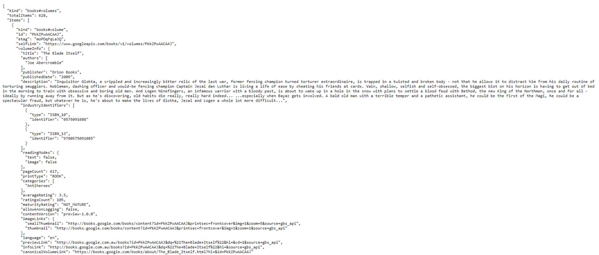

Once familiar with the data dictionary structure of the Google Books API, the next step involved creating a loop to run individual queries for each title scraped from the Goodreads website.

Within the loop of titles, a Request function returns the search results as a json object so individual data items can be extracted from the nested data within. The following code block applies these title queries in a loop and appends content from the first search result to pre-set Supplements data frame, to be stored and later merged with the scraped Goodreads data.

However each of these queries will contain a similar, but not identical structure and content as the image above. With some absent content not listed in all returned dictionaries. For this reason, preliminary examination of the data will be required.

```python
# import the Goodreads scraped data csv
df = pd.read_csv('scraped_df.csv')

# create a blank dataframe to append results to
supplements = pd.DataFrame(columns=['title', 'api_title', 'api_authors', 'api_publisher',
                                    'api_published_date', 'api_page_count', 'api_print_type',
                                    'api_description', 'api_language'])

# loop requests data from the api
for title in df.title:
    url = "https://www.googleapis.com/books/v1/volumes?q=" + quote(title)

    # request data from the url as a json dict
    data = requests.get(url).json()

    # isolate the required fields from the first (i.e. [0]) search result in each instance
    try:
        api_title = data['items'][0]['volumeInfo']['title']
    except:
        api_title = ''
    try:
        api_authors = data['items'][0]['volumeInfo']['authors']
    except:
        api_authors = ''
    try:
        api_publisher = data['items'][0]['volumeInfo']['publisher']
    except:
        api_publisher = ''
    try:
        api_published_date = data['items'][0]['volumeInfo']['publishedDate']
    except:
        api_published_date = ''
    try:
        api_page_count = data['items'][0]['volumeInfo']['pageCount']
    except:
        api_page_count = ''
    try:
        api_print_type = data['items'][0]['volumeInfo']['printType']
    except:
        api_print_type = ''
    try:
        api_description = data['items'][0]['volumeInfo']['description']
    except:
        api_description = ''
    try:
        api_language = data['items'][0]['volumeInfo']['language']
    except:
        api_language = ''

    # gather new data into numpy array and convert to a pandas dataframe
    title = title
    gateway = np.array([title, api_title, api_authors, api_publisher,
                        api_published_date, api_page_count, api_print_type,
                        api_description, api_language]).reshape(1, 10)
    gateway = pd.DataFrame(gateway, columns=['title', 'api_title', 'api_authors', 'api_publisher',
                                             'api_published_date', 'api_page_count', 'api_print_type',
                                             'api_description', 'api_language'])

    # append this data frame for each unique title search produced
    supplements = supplements.append(gateway)

# convert to csv
supplements.to_csv('Supplements.csv', index=False)
```

### Data Wrangling

With both the scraped and supplementary data stored as raw CVS files, containing 1,250 records apiece, the next preparation phase involved merging, cleansing and evaluating the various derived fields for usability in analysis.

```python
# import the goodreads scraped data
scraped = pd.read_csv('scraped_df.csv')
# import supplementary google API data
supplements = pd.read_csv('Supplements.csv')
# join with subset dataframe
df = pd.merge(scraped, supplements)
```

The first field evaluated was the scraped titles themselves, to ensure no duplicates progressed to analysis.

```python
# explore the full list of titles
# print the top 5 titles by frequency
print(pd.DataFrame(df["title"].value_counts(ascending=False)).head())
# Note - There are instances where a title appears more than once
# retain a single instance of each unique title
df = df.drop_duplicates(subset='title', keep='last')
```

The was followed by the API derived language field, to ensure the corpus encoded in NLP processing only contains English words.

```python
# explore the language each books is written in
print(df["api_language"].value_counts(ascending=False))
# Note - 1,215 out of 1,248 are published in english
# subset to only include the english texts
df = df[df.api_language == 'en']
```

The original scraped description field, as mentioned contained missing cases that needed to be supplemented by the Google Books API. So the next step involved replacing missing cases from the Goodreads field with the API derived description and removing any remaining missing cases.

```python
# explore the description fields
print("Missing goodreads descriptions: " + str(df['description'].isna().sum()))
# replace missing descriptions with the API supplement
df.description.fillna(df.api_description, inplace=True)
print("Remaining missing descriptions: " + str(df['description'].isna().sum()))
# drop the remaining cases of missing description
df = df[df['description'].notna()]
```

```python
# explore the ratings fields
df['rating_count'] = df['rating_count'].str.replace(',', '').apply(pd.to_numeric)
print("The range for avg_rating is: Min(" + str(df.avg_rating.min()) + ") to Max (" + str(df.avg_rating.max()) + ")")
print("The range for rating_count is: Min(" + str(df.rating_count.min()) + ") to Max (" + str(df.rating_count.max()) + ")")
# Note - there appear to be some extreme outliers (i.e., greater than 1M ratings)
print(df.title[df.rating_count > 1000000])
# Note - these are simply very popular generic fantasy and should be excluded
df = df[(df['rating_count'] > 0) & (df['rating_count'] < 1000000)]

# now we need to derive a weighted rating for analysis
df["wavg_rating"] = df["avg_rating"] * df["rating_count"]
# but this should really be scaled to a range of 0 to 5 for ease of interpretation
df["wavg_rating"] = minmax_scale(df["wavg_rating"], feature_range=(0, 5), axis=0, copy=True)
# and finally create a flag above or below the median of this scaled rating
df["rating_class"] = np.where(df["wavg_rating"] > df["wavg_rating"].median(), "High", "Low")
```

With a serviceable rating field derived, the next field to consider for competitor relevance was the authors.

```python
# explore the authors each book is written by
print(df["author"].value_counts(ascending=False))

# "Adrian   Collins" only writes grimdark magazine, which is not a competitor for novels
df = df[df.author != "Adrian   Collins"]

# Hiroya Oku writes manga and should be excluded
df = df[df.author != "Hiroya Oku"]
```

This was followed by replacing missing cases of api_publisher with the first non-missing publisher listed against the same author. Under the rationale that each authors grimdark novels were published by the same entity. With any remaining missing cases removed since further analysis may involve this field.

```python
# explore the publishers each book is printed by
print(df["api_publisher"].value_counts(ascending=False))
missing_pubs = df[df.api_publisher.isna()]
# Note - 167 titles has missing publishers
# create a dataframe with all authors and their non-missing publishers
auth_pubs = df[["author", "api_publisher"]]
auth_pubs = auth_pubs[auth_pubs['api_publisher'].notna()]
auth_pubs = auth_pubs.drop_duplicates(subset='author', keep='first')
auth_pubs = auth_pubs.rename(columns={'api_publisher': 'lead_publisher'})
# merge the deduplicated list of authors and their leading publishers
df = df.merge(auth_pubs, how='left', on='author')
# replace missing api_publisher with the merged lead_publisher
df.api_publisher.fillna(df.lead_publisher, inplace=True)
# drop any remaining missing cases
df = df[df['api_publisher'].notna()]
```

This then led to consideration of the length of each grimdark text (i.e., api_page_count), with direct competitors for this genre not including novellas. Visualisation showed there were outliers that needed to be removed from the analysis.

```python
# explore the size of each book by supplementary api_page_count
print("api_page_count: Min(" + str(df.api_page_count.min()) + ") and Max (" + str(df.api_page_count.max()) + ")")
# Note - there appear to be some outliers in the range
# Let's visualise the distribution before making a decision
plt.plot(df['api_page_count'].value_counts())
plt.xlabel("Number of Pages")
plt.ylabel("Frequency")
plt.show()
# there are certainly outliers, but only those with too few pages (i.e., < 100) need removing
df = df[df.api_page_count > 100]
```

[output not shown]

Which was followed by deriving a field to describe the number of characters (excluding blank spaces) in each description. Those with less than 50 characters were removed as insufficient to contribute to any planned NLP analysis.

```python
# explore the length of each titles scraped/supplemented description
df['desc_length'] = df['description'].apply(lambda x: len(x) - x.count(' '))
print("desc_length: Min(" + str(df.desc_length.min()) + ") and Max (" + str(df.desc_length.max()) + ")")
# Note - there appear to be some outliers that need removing
plt.hist(x=df.desc_length)
plt.xlabel("Length of Description")
plt.ylabel("Frequency")
plt.show()
# Note - there appears to be descriptions below 50 characters that need removing
df = df[df.desc_length > 50]
```

[output not shown]

And lastly, the data frame was limited to the fields required for analysis, with the remaining 1,019 records stored locally as a user-friendly CSV.

```python
# since not all are beneficial to the analysis, we should retain only the required fields
df = df[["title", "description", "desc_length", "author",
         "avg_rating", "rating_count", "wavg_rating", "rating_class",
         "api_publisher", "api_page_count"]]

# convert to munged dataframe to csv
df.to_csv('munged_df.csv', index=False)
```

### The Resulting Data

With the base data harvested, merged and cleansed for suitability, the next step was a preliminary exploratory data analysis, which Katari (2020) describes as what the data tells us beyond formal modeling, typically on a univariate and bivariate level.

The first step in this process involved the Pandas describe() function summarising all numeric (i.e., int and float) fields and a simple frequency of publishers.

```python
# Univariate analysis: summary of the numeric (i.e., int and float) fields
print(df[["desc_length", "avg_rating", "rating_count", "wavg_rating", "api_page_count"]].describe())

# Univariate analysis: frequency of publishers
publishers = df["api_publisher"].value_counts(ascending=False)
print(publishers[publishers > 4])
```

[output not shown]

As far as central attributes, this showed that grimdark novels overall were a median of 416 pages long, with a median description length of 660 characters. Also, while the median rating of 4.1 (out of 5) was delivered for this subgenre overall by a median of 2,177 users, the scaled weighted average sits well below 1 (out of 5). In fact, some of the more popular titles recieved over 700k individual ratings apiece.

Further, no one publisher dominates the market, though Hachette UK are responsible for 227/1,019 grimdark titles scraped. Household labels like RandomHouse, HarperCollins and Macmillan are sprinkled amongst a long list of less notable publishers.

However, such one dimensional descriptives only skim the surface, with bivariate analysis drilling down into the differences among high/low performing titles.

```python
# Bivariate review: scatter plot of the scaled weighted average variable against attributes
df.plot.scatter(x="wavg_rating", y="desc_length").set(ylim=(0, 3000))
plt.savefig('wavg_by_desc.png', bbox_inches='tight')
plt.show()

df.plot.scatter(x="wavg_rating", y="api_page_count")
plt.savefig('wavg_by_page.png', bbox_inches='tight').set(ylim=(0, 3000))
plt.show()
```

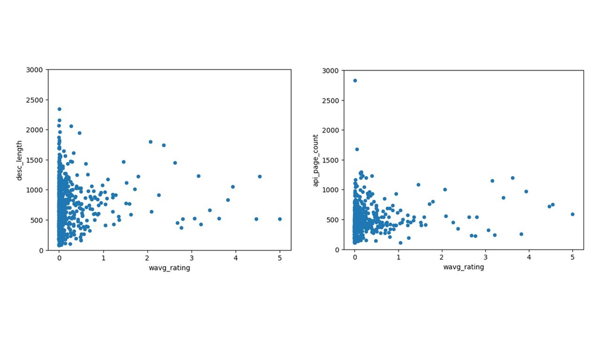

Both scatterplots of the wavg_rating, examined against the number of pages (api_page_count) and length of blurb/description (desc_length), show no immediate recognisable correlation present. However, those titles with a wavg_rating greater than 1 (out of 5) typically ranged between 200 and 1,200 pages, with an accompanying description of between 500 and 1,800 characters in length.

In an attempt to view the distribution of results from a different angle, the categorical version of the wavg_rating (i.e., rating_class) was used to generate boxplots to view the central tendancies and spread of page count and description length.

```python
# Bivariate Numeric/Categorical Analysis: high/low performance titles by length
print(df.groupby('rating_class')['desc_length'].median())
sns.boxplot(df.rating_class, df.desc_length).set(ylim=(0, 3000))
plt.savefig('class_by_desc.png', bbox_inches='tight')
plt.show()

print(df.groupby('rating_class')['api_page_count'].median())
sns.boxplot(df.rating_class, df.api_page_count).set(ylim=(0, 3000))
plt.savefig('class_by_page.png', bbox_inches='tight')
plt.show()
```

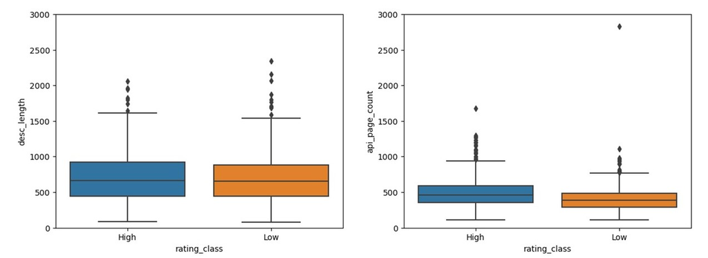

This numeric versus categorical angle determined that, while there is some minor variation across the interquartile range, there is no discernable difference between the derscription length (desc_length) of high and low performing titles.

However, this was not the case for the number of pages in a novel (api_page_count), with high performing titles (median=456 pages) being notably greater than low performing (median=384 pages). This implies novels with more depth are recieved more favourably among grimdark readers, with some high performing outliers even ranging between 1,000 and 1,700 pages.

### References

- Chandra, R. V., & Varanasi, B. S. (2015). Python requests essentials. Packt Publishing Ltd.
- Demarest, A. (2021). What is Goodreads? Everything you need to know about the popular site for readers and book recommendations. Business Insider Australia. https://www.businessinsider.com.au/what-is-goodreads?r=US&IR=T
- Harris, C. R., Millman, K. J., van der Walt, S. J., Gommers, R., Virtanen, P., Cournapeau, D., … Oliphant, T. E. (2020). Array programming with NumPy. Nature, 585, 357–362. https://doi.org/10.1038/s41586-020-2649-2
- Hunter, J. D. (2007). Matplotlib: A 2D graphics environment. Computing in Science & Engineering, 9(3), 90–95.
- Kashif, J. (2020). Python BeautifulSoup Scraper that scrapes book covers, titles, descriptions, average rating, rating and authors from www.goodreads.com. https://gist.github.com/kashiftriffort/a2e7ad06dca5acc38a76007465fe6226
- Katari, K. (2020). Exploratory Data Analysis(EDA): Python - Towards Data Science. Medium. https://towardsdatascience.com/exploratory-data-analysis-eda-python-87178e35b14
- Nyar, K. (2018). Python BeautifulSoup Scraper that scrapes book covers, titles and authors from www.goodreads.com. https://gist.github.com/kyawkn/bb2c3f6d5e181a8aade0224553878040
- Pedregosa, F., Varoquaux, Ga"el, Gramfort, A., Michel, V., Thirion, B., Grisel, O., … others. (2011). Scikit-learn: Machine learning in Python. Journal of Machine Learning Research, 12(Oct), 2825–2830.
- Reback, J. (2021). pandas-dev/pandas: Pandas 1.3.4. Zenodo. https://zenodo.org/record/5574486
- Richardson, L. (2021). Beautiful Soup: We called him Tortoise because he taught us. BeautifulSoup. https://www.crummy.com/software/BeautifulSoup/
- Saving multiple api calls in a json file in Python. (2019). https://stackoverflow.com/questions/54755971/saving-multiple-api-calls-in-a-json-file-in-python
- Sen, O. (2021). Data Scraping Goodreads using Python BeautifulSoup - MLearning.ai. Medium. https://medium.com/mlearning-ai/data-scraping-goodreads-using-python-beautifulsoup-3f4f16960255
- Sevil, C. (2019). It is Legal to Scrape Data From Another Business’ Website? LegalVision. https://legalvision.com.au/scrape-data/
- Terms of Use. (2021). Goodreads. https://www.goodreads.com/about/terms
- Van Rossum, G. (2020). The Python Library Reference, release 3.8.2. Python Software Foundation.
- Waskom, M. (2017). Seaborn. Zenodo. https://zenodo.org/record/883859
- WebDriver. (2021). Selenium. https://www.selenium.dev/documentation/webdriver/
- Wille, M. (2021). Amazon’s Goodreads is ancient and terrible. Now there’s an alternative. Input. https://www.inputmag.com/reviews/amazon-goodreads-books-alternative-the-storygraph